# Como calcular Índices de Biodiversidade

Victor Lobato dos Santos

# 1 Bibliotecas utilizadas

```r
library(vegan)
library(tidyverse)
library(forcats)
library(iNEXT)
library(ggplot2)
```

# 2 Como preparar seus dados

O primeiro passo para se calcular índices de biodiversidade, é preparar os dados a serem utilizados. Existem diferentes formas de se preparar os dados para calcular índices de diversidade, aqui, utilizaremos uma forma simples e prática.

- Em sua planilha (excel, google planilhas, etc) certifique-se de que a primeira linha se refere as espécies ou morfoespécies observadas (EX: sp1, sp2, sp3…).
- As linhas abaixo, deverão corresponder ao número de indivíduos correspondentes a cada espécie e campanha (1, 0 , 5, 3…)
- • Após o preparo, salve sua tabela em formato **CSV Delimitado por vírgula**.

O próximo passo é importar a tabela para o Rstúdio. Utilizaremos como exemplo um banco de dados fictício de 20 espécies diferentes de aranhas, coletadas em duas campanhas (amostras) diferentes, sendo a primeira campanha de uma estação chuvosa e a segunda de uma estação seca. Daremos o nome ao nosso banco de dados de bd_aranhas.csv

Antes de importar seus dados, certifique-se de que seu ambiente de trabalho no RStúdio está utilizando o diretório correto. Você pode selecionar o diretório utilizando o atalho *CTRL + SHIFT + H*.

Utilizaremos o seguinte código:

```r
dados_aranhas <- read.csv("bd_aranhas.csv",
                          sep = ";",
                          header = TRUE)
```

Podemos visualizar os dados brevemente, utilizando a função `head(dados_aranhas)`, ou através do painel Environment localizado no canto superior direito da tela.

```r
head(dados_aranhas)
```

```
##   sp1 sp2 sp3 sp4 sp5 sp6 sp7 sp8 sp9 sp10 sp11 sp12 sp13 sp14 sp15 sp16 sp17
## 1  10   8  12   7   9  11   6  10   8   12    7    9   11    6   10    8   12
## 2   2   1   0   3   1   2   0   1   2    0    1    0    2    1    0    1    2
##   sp18 sp19 sp20
## 1    7    9   11
## 2    0    1    2
```

Observe mais uma vez que neste banco de dados, as colunas representam espécies (sp) enquanto que as linhas representam as campanhas / amostragens.

# 3 Índices de Diversidade e Equitabilidade

Antes de calcular os índices de diversidade no R, primeiro devemos descobrir a riqueza e riqueza total das espécies de nossos dados. Para isso utilizaremos a função **specnumber()** da biblioteca **vegan** e a função **colSums** pertencente a biblioteca base do R.

```r
# Riqueza
riqueza <- specnumber(dados_aranhas)
riqueza
```

```
## [1] 20 14
```

```r
#Riqueza Total

riqueza_total <- specnumber(colSums(dados_aranhas))
riqueza_total
```

```
## [1] 20
```

## 3.1 Índice de Shannon-Wiener

O índice de Shannon-Wiener pode ser calculado no R de diferentes maneiras, mas iremos calcula-lo através da função `diversity()`, também do pacote **vegan**. É interessante que seja calculado não apenas o índice individual de cada campanha, mas também o índice total.

```r
shannon <- diversity(dados_aranhas,
                     index = "shannon")
shannon
```

```
## [1] 2.973084 2.563151
```

Geralmente, o índice de Shannon varia em uma faixa entre 1,5 a 3,5, em que, valores próximos a 1,5 indicam baixa diversidade e valores próximos a 3,5 indicam alta diversidade. Em nosso resultado exemplo, obtivemos os valores de 2,973 para a primeira campanha e 2,563 para segunda campanha.

```r
shannon_total <-  diversity(colSums(dados_aranhas),
                            index = "shannon")
shannon_total
```

```
## [1] 2.972296
```

O valor para o índice de Shannon total foi de 2,972.

## 3.2 Índice de Simpson

```r
simpson <- 1 - diversity(dados_aranhas,
                         index = "simpson")
simpson
```

```
## [1] 0.05222610 0.08264463
```

Obtivemos os resultados de 0,052 para a primeira campanha e 0,082 para a segunda campanha.

```r
simpson_total <- 1 - diversity(colSums(dados_aranhas),
                              index = "simpson")

simpson_total
```

```
## [1] 0.05227841
```

## 3.3 Índice de Equitabilidade Pielou

Os valores do índice de Pielou (J) , geralmente variam de 0 a 1, onde quanto mais próximo de 1 maior é a equitatividade e quanto mais próximo de 0, indica uma maior desigualdade dentro da comunidade, apresentando uma ou algumas espécies dominantes.

O índice de Pielou pode ser calculada utilizando a função de `log()` e `specnumber()` pertencente ao pacote vegan.

```r
pielou <- shannon / log(specnumber(dados_aranhas))
pielou
```

```
## [1] 0.9924398 0.9712375
```

Obtivemos os resultados de 0,992 para primeira campanha e 0,971 para segunda campanha.

```r
pielou_total <- shannon_total / log(riqueza_total)
pielou_total
```

```
## [1] 0.9921766
```

Para o resultado de Pielou total, obtivemos o valor de 0,992.

# 4 Curva de Rarefação

## 4.1 Preparando a tabela

Para construir o gráfico da curva de rarefação, iremos adaptar a nossa tabela para que as linhas e colunas sejam demonstradas corretamente no gráfico. Aqui, utilizaremos três colunas: especies, campanha_1, campanha_2. A coluna especies será referente as sp (sp1, sp2, sp3…), a segunda e terceira coluna será referente ao número de indivíduos coletados em cada campanha.

```r
dados_rarefacao <- read.csv("dados_aranhas_rarefacao.csv",
                            sep = ";",
                            header = TRUE)
```

```r
head(dados_rarefacao, 10)
```

```
##    especies campanha_1 campanha_2
## 1       sp1         10          2
## 2       sp2          8          1
## 3       sp3         12          0
## 4       sp4          7          3
## 5       sp5          9          1
## 6       sp6         11          2
## 7       sp7          6          0
## 8       sp8         10          1
## 9       sp9          8          2
## 10     sp10         12          0
```

Primeiro, iremos selecionar as colunas que irão compor o gráfico:

```r
colunas_selecionadas <- dados_rarefacao[, 2:3]
```

Em seguida, iremos utilizar a função **iNEXT** da biblioteca iNEXT para criar nosso gráfico.

```r
out <- iNEXT(colunas_selecionadas, q=0,
             datatype = "abundance",
             size = seq(0, 200,
                        length.out = 20))
```

Neste script utilizamos a biblioteca iNEXT e algumas de suas funções. Vamos entender o que foi feito:

- Utilizamos o parâmetro `q=0` para especificar a ordem de diversidade que queremos, que nesse caso, é a riqueza de espécies. Caso quiséssemos utilizar o valor de Shannon, adaptaríamos para `q=1` e `q=2` para Simpson.
- Em `datatype = "abundance"` especificamos o tipo de dados que será utilizado, que neste caso, foram os dados de abundância. Caso quiséssemos por exemplo, utilizar dados de incidência (presença ou ausência), poderíamos adequar o parâmetro para datatype = “incidence”.
- O parâmetro `size = seq(0, 200, length.out = 20)` é utilizado para definir o tamanho que a amostra deverá ser estimada, enquanto que a função seq() é utilizada para gerar uma sequência de números, e, o parâmetro `length.out = 20` é utilizado para especificar que a sequência criada, deve ter 20 pontos igualmente espaçados.

Por fim, para criar nosso gráfico de rarefação, iremos utilizar a biblioteca **ggiNext** e **ggplot2**.

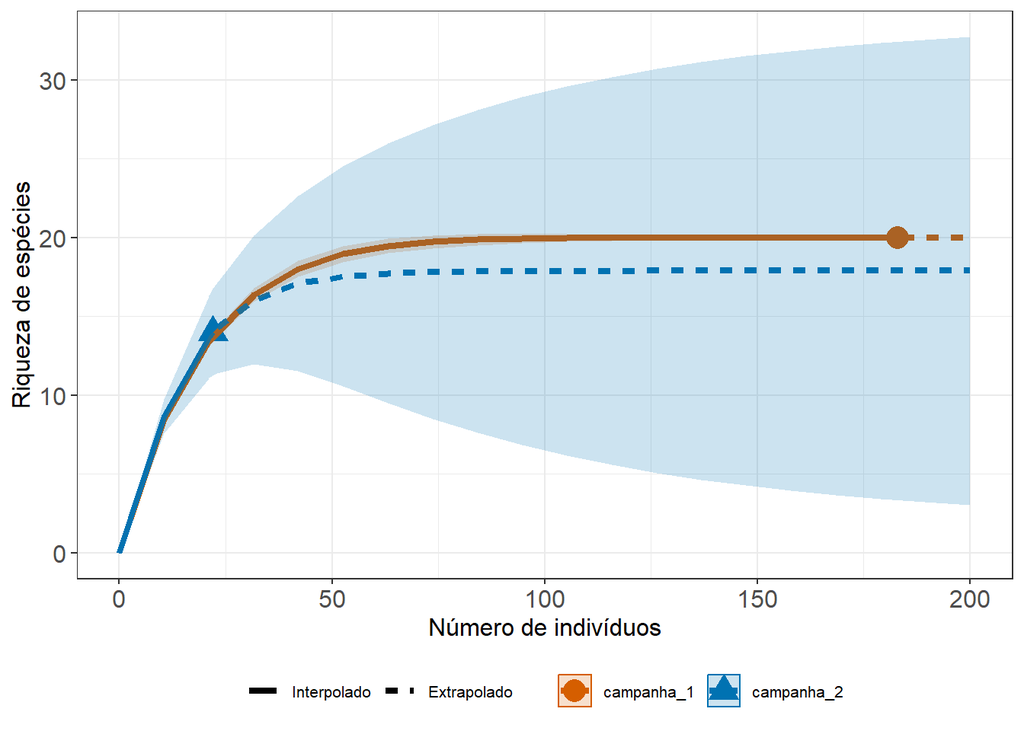

```r
gg_rarefacao <- ggiNEXT(out, type = 1) +
  theme_bw() +
  scale_linetype_discrete(labels = c("Interpolado", "Extrapolado")) +
  labs(x = "Número de indivíduos", y = "Riqueza de espécies") +
  theme(legend.title=element_blank()) +
  theme(
    axis.text.x = element_text(size = 12),
    axis.text.y = element_text(size = 12),
    axis.title.x = element_text(size = 12),
    axis.title.y = element_text(size = 12),
    legend.title = element_text(size = 12),
    legend.text = element_text(size = 8),
    legend.position = "bottom"
  )

gg_rarefacao
```

### 4.1.1 Explicando a construção do gráfico

O gráfico de rarefação criado foi construído utilizando as seguintes funções e parâmetros:

- O parâmetro `out` retorna o resultado feito pela análise de diversidade através do **iNEXT**.
- Em `type = 1` nos demonstramos que o gráfico construirá a curva de rarefação com base no número de indivíduos.
- A função `theme_bw()` pertence ao pacote **ggplot2** e permite aplicar um tema pré definido ao layout do gráfico.
- A função `scale_linetype_discrete` do **ggplot2** permite personalizar as linhas do gráfico. Enquanto que, o parâmetro `labels =` permite definir o nome para os rótulos da legenda.
- A função `labs()` nos permite modificar ou adicionar nomes aos rótulos dos eixos do gráfico.
- A função `theme()` é utilizada para personalizar alguns aspectos visuais do gráfico, como cores, tamanho de legendas, títulos, etc.
- Os parâmetros `axis.text`, `axis.title` e `legend.title` podem ser utilizados para alterar o tamanho dos textos presente no gráfico.
- O parâmetro `legend.position =` é utilizado para definir a posição da legenda no gráfico.